# Stratification and Social Mobility

Dr. Fatima Alqabandi · Kuwait University

Chapter 8 · Based on Richard T. Schaefer, *Sociology: A Brief Introduction*, 14th ed.

# Jerome Powell on Inequality and the Middle Class

In 2019 the head of the U.S. central bank warned that the middle class was losing ground. His speech raises this chapter’s questions: who gets what, why, and how easily people move up or down.

## Predict: How Many Middle-Class Children Out-Earn Their Parents?

- **Jerome Powell** became chair of the U.S. Federal Reserve on February 5, 2018. The Federal Reserve regulates the banking system and helps keep the economy on track
- In May 2019 he spoke to researchers and policymakers at a Chicago Federal Reserve conference about the future of the middle class

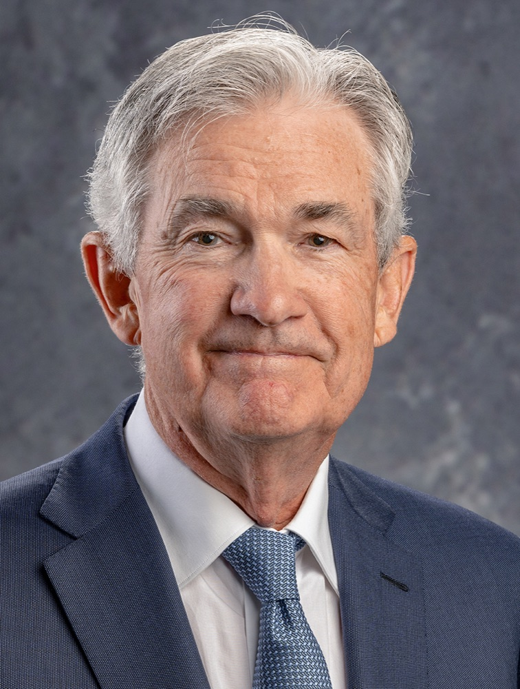

Jerome Powell. Federal Reserve, public domain.

In the 1950s, what share of U.S. children born into middle-class households grew up to earn more than their parents? What share do today?

- In the 1950s, **better than 80 percent**. More recently, **only around half** (Powell 2019)
- “The kind of generational improvements in living standards that were long the hallmark of the American middle class have steadily diminished”

## Powell’s Three Observations About the U.S. Middle Class

1. **Income growth and upward mobility have slowed for the middle.** Since the 1970s, middle-class incomes have grown more slowly than high incomes, so income inequality has widened. Slower productivity growth also played a part
2. **The gap between college graduates and everyone else is widening.** From 1967 to 2017, employment fell among working-age men at every level of education, and it fell furthest for men without a college degree
3. **Moving up depends on more than effort and talent.** It depends on your family, the neighborhood you grow up in, and the quality of your primary and secondary schools. Children from higher-income households are much more likely to attend college, and that advantage has grown since the 1980s

## Powell: Employment Among U.S. Working-Age Men by Education, 1967 and 2017

[figure not shown]

# Systems of Stratification

Every society ranks its members. Sociologists ask how rigid the ranking is: whether your position is fixed at birth or can change through what you do.

## Social Inequality and Stratification Defined

- **Social inequality** — a condition in which members of society have differing amounts of wealth, prestige, or power. All societies show some degree of social inequality
- **Stratification** — a structured ranking of entire groups of people that perpetuates unequal economic rewards and power in a society
- Stratification is how **one generation passes social inequalities on to the next**, producing groups ranked from low to high
- It results inevitably in social inequality: certain groups stand higher, control scarce resources, wield power, and receive special treatment
- The unequal rewards appear in the distribution of wealth and income, and even in the **mortality rates** of impoverished communities

Inequality describes differences between individuals. Stratification describes a ranking of whole groups that lasts across generations.

## Income and Wealth Are Not the Same Thing

- **Income** — salaries and wages, interest on savings, stock dividends, and rental income
- **Wealth** — all of a person’s material assets, including land, stocks, and other types of property

[figure not shown]

## Income or Wealth? Sort the Items

Classify each item as income or wealth. Some items produce the other.

1. A monthly salary from a ministry
2. Rent collected from an investment building
3. A chalet in Khiran
4. Shares in a Kuwaiti bank
5. The yearly dividend on those shares
6. A plot of land inherited from a grandfather
7. Interest on a savings account
8. Gold jewelry received at a wedding

Two employees earn the same salary. One also inherited a building. Who is safer if both lose their jobs tomorrow? Whose children start further ahead?

## Ascribed and Achieved Status Shape Every System of Stratification

- **Ascribed status** — a social position assigned to a person by society without regard for the person’s unique talents or characteristics (Chapter 5)
- **Achieved status** — a social position a person attains largely through his or her own efforts
- The two are closely linked. The most affluent families generally **inherit** wealth and status, while many members of racial and ethnic minorities inherit **disadvantaged** status. Age and gender are ascribed statuses that also influence wealth and social position
- Schaefer describes **four systems of stratification**: slavery, castes, estates, and social classes. Treat them as **ideal types** (Chapter 1). Any real system may include elements of more than one

## Four Systems of Stratification, from Closed to Open

[figure not shown]

Before the U.S. Civil War, for example, the southern states had both social classes dividing white people from one another and the institutionalized enslavement of Black people.

## Slavery: The Most Extreme Form of Legalized Inequality

- **Slavery** — a system in which enslaved individuals are **owned by other people**, who treat them as property, just as if they were household pets or appliances
- **Ancient Greece:** enslaved people came mainly from piracy and captives of war. Children could inherit the status, but it was not necessarily permanent. A person’s status might change depending on which city-state won a war
- **The United States and Latin America:** slavery was an **ascribed** status, and racial and legal barriers prevented the freeing of enslaved people
- In both Europe and the New World, the rise of slavery was **essential to the growth of capitalism** in the 19th century (Desmond 2019)
- The **Universal Declaration of Human Rights**, binding on all UN members, prohibits slavery in all its forms. Yet **more people are enslaved today** than at any point in world history: over **40 million** at any given time (Walk Free Foundation 2019)
- Today’s forms include **bonded laborers** held in virtual lifetime employment, and guest workers and undocumented workers in Europe and the United States forced to labor for years to pay off debts or to avoid being turned over to immigration authorities. Both involve the transnational crime of **trafficking in humans** (Chapter 7)

## Castes: Hereditary Ranks That Are Hard to Leave

- **Castes** — hereditary ranks that are usually religiously dictated and tend to be fixed and immobile. Children automatically take their parents’ position, and members are expected to **marry within their caste**
- The caste system is generally associated with **Hinduism in India**. There are four major castes, called **varnas**
- A fifth category of outcastes, the **untouchables**, makes up **16 percent** of the population. They are considered so lowly and unclean as to have no place within the system
- To avoid perpetuating the stigma, the government now calls them **scheduled castes**. They themselves prefer **Dalit** (“the repressed”), a term that expresses their desire to overcome their disadvantaged status
- In **1950**, after independence from Great Britain, India’s new constitution **formally outlawed** the caste system
- Over the past decade or two, **urbanization and technology** have changed the caste system more than government or politics has in half a century. The anonymity of city life lets Dalit pass unrecognized in temples, schools, and workplaces, and the globalization of high technology has opened new opportunities
- The term applies beyond India: the southern United States from the end of the Civil War through the 1960s, and South Africa under **apartheid** (1948 through the 1990s). In both, race defined a person’s place (Wilkerson 2020)

## Discuss: How City Anonymity Weakens Caste Boundaries

India outlawed caste in 1950. Yet Schaefer says city life and technology have done more to change the system in the last few decades than the law did in half a century.

- What does a stranger in a crowded city know about you? What did your neighbors in a village know?
- Which settings still let people learn your family background quickly: a wedding, a job interview, a diwaniya, a WhatsApp group?
- What does this suggest about where ascribed status matters most: in law, or in everyday interaction?

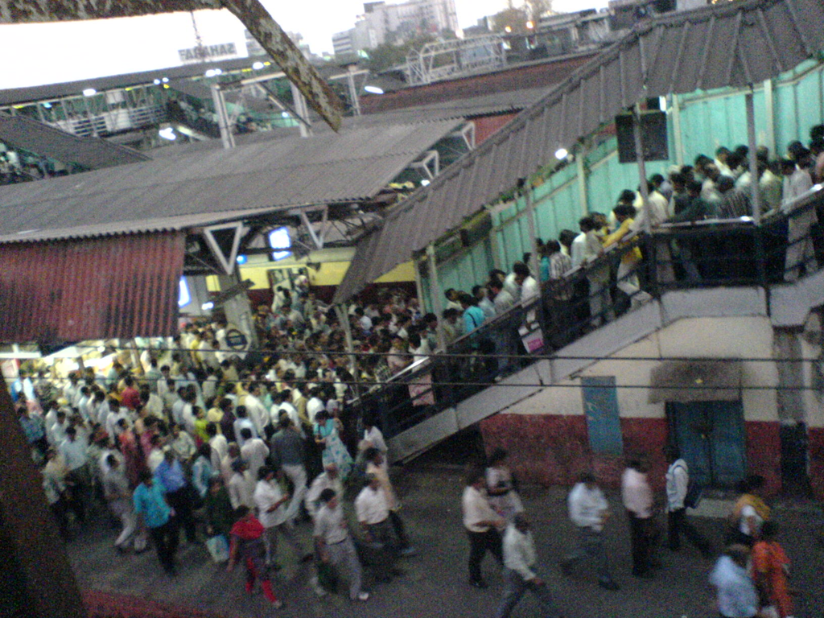

Evening commuters at Bandra station, Mumbai, 2006. Rakesh from Bangalore, CC BY-SA 2.0.

## Estates: Nobles, Peasants, and Land in Feudal Europe

- **Estate system** (feudalism) — peasants worked land leased to them by nobles in exchange for military protection and other services. It was associated with feudal societies during the Middle Ages
- The nobles’ **ownership of land** was the basis of their superior and privileged status
- As in slavery and caste, **inheritance** largely defined a person’s position. Nobles inherited titles and property; peasants were born into a subservient position in an agrarian society
- By the **12th century**, a priesthood had emerged in most of Europe, along with classes of **merchants and artisans**. For the first time, some groups had wealth that did not depend on land or agriculture
- This economic change ended the estate system, and a **class system** of stratification came into existence

[figure not shown]

Peasants work the fields below the lord’s castle. Limbourg brothers, *Très Riches Heures du Duc de Berry*, “March,” c. 1412–1416. Public domain.

## Social Classes: A Ranking by Economic Position

- **Class system** — a social ranking based primarily on economic position in which **achieved characteristics can influence social mobility**
- Unlike slavery and caste, the boundaries between classes are **imprecisely defined**, and people can move from one stratum, or level, to another
- Class systems still maintain stable hierarchies and are marked by unequal distribution of wealth and power
- Class standing, though achieved, is **heavily dependent on family** and on ascribed factors such as ethnicity
- Sociologist **Daniel Rossides** (1997) uses a **five-class model** of the United States. Its lines are not as sharp as caste divisions, but the five classes differ in more than income

## Rossides’s Five-Class Model of the United States

[figure not shown]

# Sociological Perspectives on Stratification

Marx saw economic class as the key to all inequality. Weber saw three separate rankings. Interactionists watch how class shows up in what people buy and display.

## Marx: Who Controls the Means of Production?

- **Karl Marx** studied stratification in every type of society, from early agricultural tribes through feudalism, but focused on the effects of economic inequality in **19th-century Europe**. The plight of the working class made him feel that the class structure had to change
- Social relations in any period depend on **who controls the primary mode of economic production**, such as land or factories. Under feudalism the nobility owned the land, and peasants had little choice but to work on the owners’ terms
- **Capitalism** — an economic system in which the means of production are held largely in private hands and the main incentive for economic activity is the accumulation of profits
- **Bourgeoisie** — the capitalist class, which owns the means of production, such as factories and machinery. **Proletariat** — the working class
- The bourgeoisie maximize profit in competition with other firms, and in the process **exploit workers**, who must exchange their labor for subsistence wages
- Each class shares a distinctive culture. Marx was most interested in the proletariat’s, but he also examined the **ideology of the bourgeoisie**, through which it justifies its dominance over workers

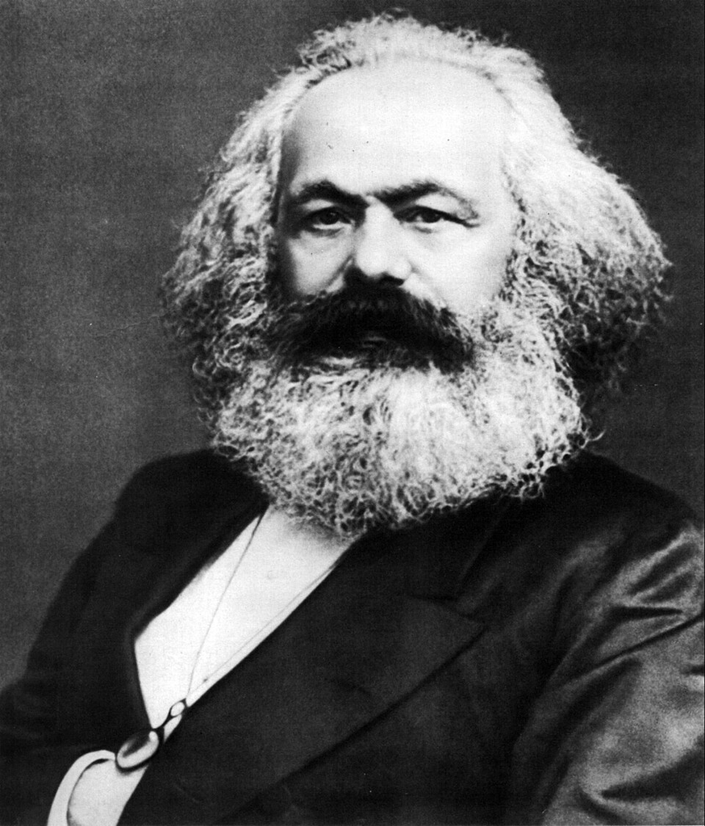

Karl Marx (1818–1883). John Jabez Edwin Mayall, public domain.

## Marx: Class Consciousness and False Consciousness

- Marx predicted that exploitation would **inevitably** lead workers to revolt and destroy capitalism
- First, workers must develop **class consciousness** — a subjective awareness of common vested interests and the need for collective political action to bring about social change
- Often they must overcome **false consciousness** — an attitude held by members of a class that does not accurately reflect their objective position

[figure not shown]

- The class-conscious worker sees that **all workers** are exploited by the bourgeoisie and share a stake in revolution. Marx expected revolutionary leaders to guide the proletariat to overthrow the bourgeoisie and the government, which he saw as representing capitalists, and to end private ownership of the means of production. In his rather **utopian** view, classes and oppression would then cease to exist

## False Consciousness or Class Consciousness? Classify the Statement

How would Marx classify each statement?

1. “My manager is unfair. I’ll move to a better company.”
2. “If I work harder than everyone else on the team, I’ll make partner.”
3. “Every junior engineer here is paid less each year while the partners’ bonuses grow. We should negotiate together.”
4. “The owner deserves the profits. He took the risk.”
5. “Every nurse on this ward is overworked. Let’s write one letter, signed by all of us.”

## How Accurate Were Marx’s Predictions?

- He failed to anticipate **labor unions**, whose collective bargaining weakens the stranglehold that capitalists hold over workers
- He did not foresee how far **political liberties and relative prosperity** could contribute to false consciousness. Many workers see themselves as individuals striving for improvement in free societies with substantial mobility, not as members of a class facing a collective fate
- Even today, “class warfare” refers more to **diminished individual expectations** than to a collective identity
- He did not predict that Communist Party rule would be established, and later **overthrown**, in the former Soviet Union and throughout Eastern Europe
- **Still useful:** the Marxist approach stresses stratification as a determinant of social behavior and the fundamental separation in many societies between the **rich and the poor**

## Weber: Class, Status Group, and Power

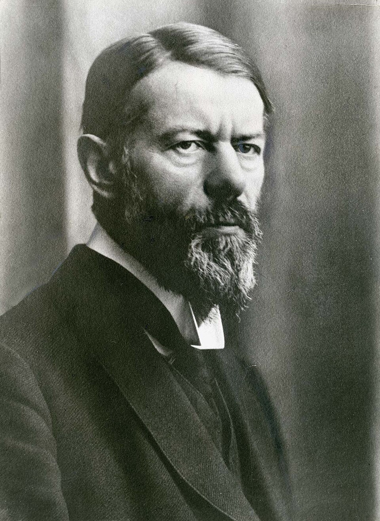

Max Weber (1864–1920), 1918. Ernst Gottmann, public domain.

[figure not shown]

## Weber: No Single Characteristic Defines Your Position

- **Max Weber**, writing in 1916, insisted that no single characteristic, such as class, totally defines a person’s position. He agreed that the economic dimension matters but argued that it cannot explain everything
- **Class** — a group of people with a similar level of wealth and income. Workers trying to support families on minimum-wage jobs form a class, because they share the same economic position and fate
- **Status group** — people who have the same prestige or lifestyle. You gain status through membership in a desirable group, such as the medical profession
- **Power** — the ability to exercise one’s will over others. In the United States it stems from membership in influential groups: corporate boards, government bodies, interest groups. Conflict theorists note that **big business and government** are closely interrelated: corporate heads move into government posts, and former government and military leaders take key roles in corporations
- Each of us has **not one rank but three**. Each influences the others, and they often coincide. **John F. Kennedy** came from an extremely wealthy family, attended exclusive preparatory schools, graduated from Harvard, and became president

## Weber’s Three Rankings Do Not Always Match: Rate Each Person

Rate each person high, medium, or low on class (wealth and income), status (prestige), and power.

1. An influencer with three million followers
2. A university professor
3. A member of the National Assembly
4. A first-year medical resident
5. A wealthy merchant’s heir who avoids public life
6. A ministry undersecretary
7. A successful pickpocket
8. A respected elder who hosts a large diwaniya

Where did the three ratings disagree most? Would Marx say the disagreement matters, or that money eventually decides the other two?

## Interactionists: Veblen’s Conspicuous Consumption

- Marx and Weber worked at the **macro** level, studying whole societies or the global economy. Marx did point toward the micro level when he asked how individuals develop class consciousness
- Interactionists, and economists, study how social class shapes a person’s **lifestyle**
- **Conspicuous consumption** — Thorstein Veblen’s (1857–1929) term for buying goods not to survive but to **flaunt** superior wealth and social standing: more cars than one can reasonably use, homes with more rooms than one can possibly occupy
- **Conspicuous leisure** — jetting to a remote destination just long enough to have dinner or watch a sunset over a historic site (Veblen [1899] 1964). Schaefer reports that the rich now spend **$275,000 to $400,000** on their children’s playhouses and tree houses
- Social media created a new outlet. Seeing friends’ vacations and new cars online can provoke **Facebook envy**. Studies in the United States and Germany show that even otherwise happy people can suffer envy and distress from digitally shared conspicuous consumption (Taylor and Strutton 2016)

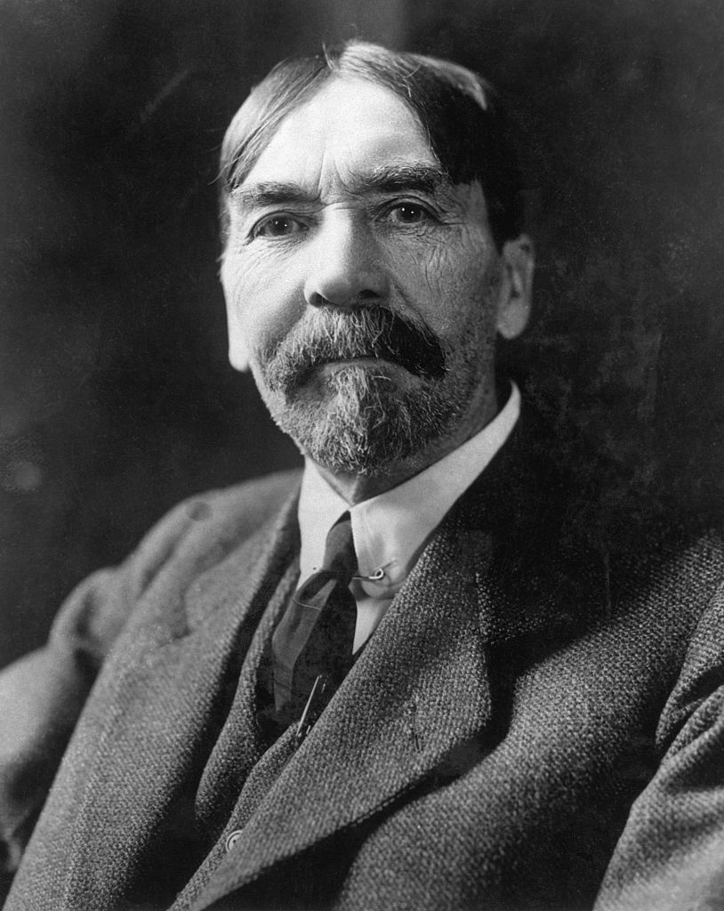

Thorstein Veblen. Public domain.

## Interactionists: Lower-Class Lifestyles Are Ridiculed and Even Restricted

- Behavior judged typical of the lower class faces not only **ridicule** but even **legal action**
- Some U.S. communities have banned trailers from front yards and sofas from front porches. In some it is illegal to leave a pickup truck in front of the house overnight
- Street vendors who sell fruit, flowers, and water face restrictions meant not to serve the public but to **protect their storefront competitors**
- During the **coronavirus pandemic**, interactionists observed that the poor could not keep their distance in the jobs they held or in their housing, from high-density public housing in U.S. cities to the tightly packed slums of Rio de Janeiro (Bassett 2020)

[figure not shown]

A sidewalk fruit stand in East Harlem, New York, 2012. Jim Henderson, CC0.

# Is Stratification Universal?

Every known society ranks its members in some way. Functionalists say the ranking does a job for society. Conflict theorists say it serves the people at the top.

## Landtman and the Kiwai Papuans: “A Little More High”

- Utopian socialists, religious minorities, and recent countercultures have all tried to build communities that would abolish inequality
- Anthropologist **Gunnar Landtman** ([1938] 1968) studied the **Kiwai Papuans** of New Guinea. At first he noticed little differentiation: every man did the same work and lived in similar housing. On closer inspection, he found a ranking:

[figure not shown]

- Stratification is **universal**: all societies maintain some form of social inequality. Depending on its values, a society may rank people by religious knowledge, hunting skill, physical attractiveness, trading expertise, or the ability to provide health care

## Functionalist View: Davis and Moore on Unequal Rewards

- Would people go to school for many years to become physicians if they could make as much money and gain as much respect as street cleaners? Functionalists say no
- **Kingsley Davis and Wilbert Moore** (1945): society must fill its positions, and fill them with people who have the right talents. Rewards, including money and prestige, depend on a position’s **importance** and the **scarcity** of qualified people
- So stratification is universal, and inequality is **necessary** to motivate people to fill functionally important positions
- **Critics:** unequal rewards are not the only motivator. Personal pleasure, intrinsic satisfaction, and values also lead people into careers
- Functionalists reply that society still needs some reward to draw people into unpleasant or dangerous jobs and into professions with long training
- **Remaining problems:** the theory devalues work done by women at home or in women’s occupations, and low-status work in fast-food outlets. It does not address systems in which status is **inherited**, such as slavery or caste. And it does not explain the **wide disparity** between the rich and the poor (R. Collins 1975; Kerbo 2012)

## Conflict View: Marx, Dahrendorf, and Authority

- Marx viewed history as a continuous struggle between oppressors and oppressed, ending in an egalitarian, classless society. Under capitalism, he argued, the bourgeoisie manipulates the economic and political systems to control the proletariat
- Marx did not believe stratification was inevitable, but he saw inequality and oppression as **inherent in capitalism** (E. O. Wright 2015)
- Contemporary conflict theorists agree that people are prone to conflict over scarce resources such as wealth, status, and power. They extend the analysis beyond class to **gender, race, age**, and other dimensions
- British sociologist **Ralf Dahrendorf** (1929–2009) adapted Marx to modern capitalist societies. For him, social classes are groups who share common interests resulting from their **authority relationships** (1959)
- The most powerful groups include not only owners but also **managers of industry, legislators, the judiciary, and heads of the government bureaucracy**. Dahrendorf merged Marx’s emphasis on class conflict with Weber’s recognition that **power** matters (Cuff et al. 1990)

## Conflict View: Dominant Ideology and Limited Reforms

- The powerful want society to run smoothly so they can enjoy their privileged positions. Because the status quo suits them, they have a clear interest in **preventing or controlling conflict**
- **Dominant ideology** — a set of cultural beliefs and practices that helps to maintain powerful social, economic, and political interests
- Conflict theorists believe the powerful control not only wealth and property but also the means of producing beliefs about reality, through **religion, education, and the media** (Knowles and Castro 2019)
- They also believe that the powerful use **limited social reforms** to buy off the oppressed. Minimum-wage laws and unemployment compensation give real help, but they also pacify people who might otherwise rebel
- Conflict theorists reject Davis and Moore: stratification is a major source of **tension**, and it will inevitably lead to **instability and social change** (R. Collins 1975; L. Coser 1977)

[figure not shown]

*Ice Road Truckers* poster. History channel.

**Schaefer’s example.** The reality series *Ice Road Truckers* ran for 11 seasons, until 2017, and showed long-haul truck drivers taking pride in a low-prestige job. In the conflict view, beliefs such as the trucker-as-hero image help the wealthy keep power at the expense of the lower classes.

## Dominant Ideology in Everyday Sayings: Classify the Statement

Dominant ideology works best when it sounds like common sense. Which of these sayings make inequality sound natural or deserved?

- “Work hard and you will get there.”
- “He deserves it. He comes from a good family.”
- “That job is beneath someone with your degree.”
- “Rich people earned it; poor people made bad choices.”
- “Everyone is middle class, really.”

Who benefits if everyone believes each saying?

## Lenski: Surplus Makes a Class System Possible

- Sociologist **Gerhard Lenski**, in his sociocultural evolution approach (Chapter 5), described how economic systems change as **technology** grows more complex, from hunting and gathering to industrial society
- In **hunting-and-gathering** societies, people focus on survival. Some inequality exists, but no class system emerges, because there is **no real wealth** to claim
- Technological advances produce a **surplus** of goods, which greatly expands the possibilities for inequality in status, influence, and power. A well-defined, rigid class system can develop
- To minimize strikes, slowdowns, and industrial sabotage, elites may share **part** of the surplus with the lower classes, but not enough to reduce their own power and privilege
- That reward system may once have served society, as functionalists contend. But in contemporary industrial society, inequality **far exceeds** what is needed to provide goods and services (Lenski 1966; Nolan and Lenski 2015)

## Functionalist, Conflict, and Interactionist Views of Stratification

|  | **Functionalist** | **Conflict** | **Interactionist** |
| --- | --- | --- | --- |
| **Key thinkers** | Davis and Moore | Marx, Dahrendorf | Veblen |
| **Why stratification exists** | Unequal rewards motivate people to fill important positions | The powerful control scarce resources and want to keep them | Class shapes lifestyles, which people display and read in everyday life |
| **Is it necessary?** | Yes, in some form | No; it is inherent in capitalism (Marx) and serves those on top | Not the main question; it asks how class shows up in interaction |
| **Its effect on society** | A source of stability | A source of tension, instability, and change | Conspicuous consumption, envy, and ridicule of lower-class lifestyles |
| **Key concepts** | Importance, scarcity, rewards | Class consciousness, false consciousness, dominant ideology | Conspicuous consumption, conspicuous leisure |

# Stratification by Social Class

We judge people’s class constantly, from their cars, homes, and clothes. Sociologists need a measure that does not depend on guesswork.

## The Objective Method of Measuring Social Class

- It is harder to place a person in a class system than in a slavery or caste system. To determine someone’s class, sociologists generally rely on the **objective method**
- **Objective method** — class is treated largely as a statistical category. Researchers assign individuals to classes using criteria such as **occupation, education, income, and place of residence**
- The **researcher**, not the person being classified, identifies the individual’s class position
- The first step is deciding which indicators to measure. The **prestige ranking of occupations** has proved especially useful, partly because it is much easier to determine accurately than income or wealth

## Prestige and Esteem

- **Prestige** — the respect and admiration that an occupation holds in a society. “My daughter, the physicist” means something very different from “my daughter, the waitress”
- Prestige belongs to the **job**, not to the person who holds it
- **Esteem** — the reputation that a specific person has earned within an occupation
- The presidency of the United States has high prestige, though the people who held it earned varying degrees of esteem. A hair stylist may have the esteem of his clients but lacks the prestige of a corporate executive
- During the pandemic, front-line occupations gained renewed respect. Nurses and EMTs (moderate prestige), and grocery clerks and delivery people (modest prestige), were even called “**heroes**”

## Predict the Prestige Scores: Teacher, Police Officer, Lawyer, Bank Teller

- In a series of national surveys, sociologists assigned prestige scores to about **500 occupations**, from surgeon to panhandler, on a scale from **0** to **100** (Table 8-3)

Rank these four from highest to lowest prestige, and guess each score: elementary school teacher, police officer, lawyer, bank teller.

- **Lawyer 76** · **Elementary school teacher 60** · **Police officer 60** · **Bank teller 50**
- The most highly regarded occupations are **physician, college professor, lawyer, dentist, and banker**
- Rankings have stayed **stable from 1925 to the present**, and similar studies in other countries have produced useful rankings too (Connelly et al. 2017)

## Table 8-3: Prestige Rankings of Occupations

| Occupation | Score |
| --- | --- |
| Physician | 86 |
| College professor | 78 |
| Lawyer | 76 |
| Dentist | 74 |
| Banker | 72 |
| Architect | 71 |
| Airline pilot | 70 |
| Clergy | 69 |
| Registered nurse | 66 |
| High school teacher | 63 |
| Pharmacist | 61 |
| Elementary school teacher | 60 |
| Veterinarian | 60 |
| Police officer or detective | 60 |
| Prekindergarten teacher | 60 |
| Accountant | 57 |
| Librarian | 55 |
| Firefighter | 53 |
| Funeral director | 52 |
| Social worker | 52 |

| Occupation | Score |
| --- | --- |
| Bank teller | 50 |
| Electrician | 49 |
| Farm manager | 48 |
| Insurance agent | 47 |
| Mail carrier | 42 |
| Farmer | 41 |
| Correctional officer | 40 |
| Carpenter | 40 |
| Barber | 38 |
| Child care worker | 36 |
| Hotel clerk | 32 |
| Bus driver | 32 |
| Truck driver | 30 |
| Salesworker (shoes) | 28 |
| Waiter and waitress | 28 |
| Cook (short-order) | 28 |
| Garbage collector | 17 |
| Janitor | 16 |
| Newspaper vendor | 15 |

100 is the highest and 0 the lowest possible prestige score. Source: T. Smith et al. 2019:3260–3266.

## Prestige and Your Choice of Major

Schaefer asks: how are students motivated by prestige in choosing their future occupations? What are the advantages and disadvantages of including prestige in career decisions?

- Think about: When you told relatives your major, what did they say? Did the reaction depend on the field?
- Which majors carry prestige here before a student has earned any esteem at all?
- What does a student lose by choosing for prestige? What might a student lose by ignoring it?

## Multiple Measures: Socioeconomic Status

- **Socioeconomic status (SES)** — a measure of social class based on **income, education, and occupation**
- Statistical methods and computers have multiplied the factors sociologists use to define class: the value of homes, sources of income, assets, years in present occupations, neighborhoods, and dual careers
- Adding these variables does not necessarily change the picture of class differences, but it measures class in a more **complex and multidimensional** way
- For a young person, such as a college student under 25, researchers use the **parents’** income, education, and occupation
- Whatever the technique, the study of stratification is a **study of inequality**: real and often dramatic differences in power, privilege, and opportunity

# Poverty

Most people see poverty as someone else’s problem. The evidence says it is far more common, and far less fixed, than the stereotype suggests.

## Absolute Poverty and Relative Poverty

- Defining poverty is hard, and government programs conceive of it in either absolute or relative terms
- **Absolute poverty** — a minimum level of subsistence that no family should be expected to live below
- The United States measures absolute poverty with a federal **poverty line**: a specific income level, adjusted each year for family size and composition. In **2020**, a family of four with **$26,200** or less fell below it. The line decides who is eligible for certain government benefits
- **Kuwait has no official poverty line.** The Central Statistical Bureau reports instead against the World Bank’s international extreme poverty line of **$1.90 a day** per person, the measure used to track the UN’s Sustainable Development Goals. By that line, **0 percent** of Kuwait’s population was poor in every year from 2012 to 2025
- A line designed for the world’s poorest countries says little about hardship in a high-income country. That is why sociologists also measure poverty in relative terms
- **Relative poverty** — a floating standard of deprivation by which people at the bottom of a society, whatever their lifestyles, are judged disadvantaged **in comparison with the nation as a whole**
- So even if the poor of 2020 are better off in absolute terms than the poor of the 1930s or 1960s, they are still seen as deserving special assistance

## Who Are the Poor? Stereotypes and Evidence

- The poor defy any simple definition, and they **counter common stereotypes**. Many people in the United States believe the poor are able to work but will not. Yet about **37 percent** of poor U.S. adults aged 18–64 work outside the home, compared with **53 percent** of all adults (Semega et al. 2019:50)
- In Kuwait, the **Public Assistance Law** (Law 12 of 2011) defines who qualifies for monthly state aid. The categories include widows, divorced women, orphans, people over 60 with no income, people whose illness prevents them from working, and the families of prisoners
- Most of these categories describe a household that has **lost its provider** or a person who **cannot work**. In 2023 the Minister of Social Affairs reported that nearly **50,000 families** were receiving this aid. Receiving aid is not the same as being poor: the law counts who the state supports, not everyone in need
- The poor are **not a static social class**. People near the edge of poverty move above it after a year or two, while others slip below. Still, hundreds of thousands stay poor for many years at a time (Goetz et al. 2019; Jäntti 2009)

Why does poverty persist, even in countries with vast wealth? Sociologist **Herbert Gans** (1995) asked: what does poverty do for people who are **not** poor?

1. Society’s **dirty work**, physically dirty or dangerous, dead-end, underpaid, and menial, gets done at low cost
2. Poverty **creates jobs** for those who serve the poor: legal ones (public health experts, welfare caseworkers) and illegal ones (drug dealers, numbers runners)
3. Identifying and punishing the poor as **deviants** upholds mainstream norms of hard work, thrift, and honesty
4. The poor **guarantee the higher status** of the rich. Psychologist **William Ryan** (1976) noted that the affluent may justify inequality by **blaming the victims** of poverty

# Life Chances

Class shapes more than what people can buy. It shapes how long they live and how well they come through disasters and epidemics.

## Weber’s Life Chances: Housing, Education, and Health

- **Life chances** — Weber’s term for people’s opportunities to provide themselves with **material goods, positive living conditions, and favorable life experiences** (Gerth and Mills 1958)
- Life chances show up in measures such as **housing, education, and health**
- A higher social class improves life chances and brings greater access to social rewards. People in lower classes must spend a larger share of their limited resources on the **necessities of life**
- Sometimes life chances are a matter of **life and death**. Despite advances in medicine, the longevity gap between the affluent and the poor remains and is **widening**: a man in the **top tenth** of earners can expect to live **14 years longer** than a man in the bottom tenth (Tavernise 2016)

## Predict: Who Survived the Titanic?

In 1912 the “unsinkable” British liner *Titanic* hit an iceberg. It did not carry enough lifeboats for everyone, and the evacuation plans covered only first- and second-class passengers. What share of first-class passengers survived? What share of third-class passengers?

[figure not shown]

## The Titanic: Survival Rates and Warnings by Class

- About **62 percent** of first-class passengers survived. Despite the rule that women and children would go first, about **a third** of them were men
- Only **25 percent** of third-class passengers survived. The first attempt to alert them came **well after** other passengers had been notified

[figure not shown]

The *Titanic* leaves Southampton, April 10, 1912. Francis Godolphin Osbourne Stuart, public domain.

## Class and the Coronavirus Pandemic

- The pandemic affected most people, but **affluent households** coped better. They had more and better health care options and could better withstand the economic fallout
- They could **work remotely**, have supplies and food delivered, and isolate if required. Their jobs usually offered **sick days**, and absence rarely cost them their jobs
- Their children had the latest **electronics** to keep studying when classes moved online
- **Precarious workers**, such as same-day deliverers and warehouse workers, had to keep working in public, exposed to the virus, or lose vital income if quarantined (Warzel 2020)

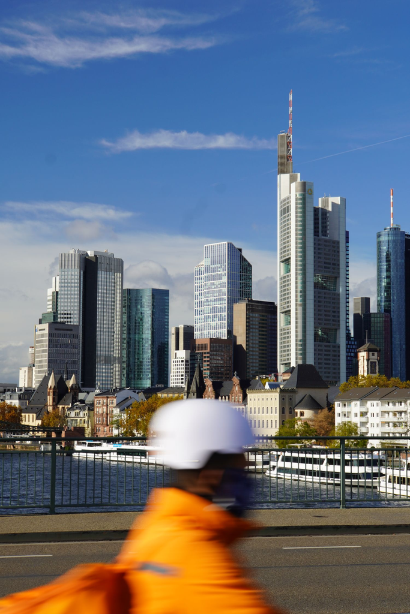

A delivery rider in Frankfurt, November 2020. CoronaBrowser.com, CC BY 4.0.

# Social Mobility

Everyone loves a rags-to-riches story. Sociologists ask how often people actually move up or down, and what makes each more likely.

## Social Mobility Defined: Open and Closed Systems

- In the movie *Maid in Manhattan*, Jennifer Lopez rises from hotel chambermaid to company supervisor and the girlfriend of a well-to-do politician
- **Social mobility** — the movement of individuals or groups from one position in a society’s stratification system to another
- **Open system** — a system in which each individual’s position is influenced by his or her **achieved** status. It encourages competition. Despite widening inequality, **60 percent** of Americans in 2019 believed people can get ahead if they are willing to work (Horowitz et al. 2020)
- **Closed system** — a system that allows little or no possibility of individual social mobility. **Slavery and caste** are examples. Placement rests on **ascribed** statuses, such as race or family background, which cannot be changed

## Horizontal and Vertical Mobility

[figure not shown]

- **Horizontal mobility** — movement from one social position to another of the **same rank**
- **Vertical mobility** — movement from one social position to another of a **different rank**, upward or downward. **Pitirim Sorokin** ([1927] 1959) first drew the distinction. Most sociological analysis focuses on vertical mobility

## Intergenerational and Intragenerational Mobility

### Intergenerational

- **Changes in the social position of children relative to their parents**
- A plumber whose father was a physician: **downward**
- Leonardo DiCaprio, raised by a single mother in a neighborhood frequented by drug dealers: **upward**
- Because education drives upward mobility, any barrier to advanced degrees limits intergenerational mobility

### Intragenerational

- **Changes in social position within a person’s adult life**
- A teacher’s aide who becomes superintendent of the school district: **upward**
- An accountant who drives a taxi after his firm goes bankrupt: **downward**

## Name the Type of Mobility

For each case: intergenerational or intragenerational? Upward, downward, or horizontal?

1. A grandfather worked on pearling ships; his granddaughter is a petroleum engineer
2. A staff nurse becomes director of nursing at the same hospital
3. A schoolteacher leaves teaching to join the police
4. A bank manager laid off at 45 now drives for a ride-hailing app
5. A doctor’s son runs a small car-repair shop
6. A junior accountant becomes chief financial officer of the same company

[figure not shown]

A diver with the Kuwaiti pearling fleet surfaces for breath, 1939. Alan Villiers, © National Maritime Museum, Greenwich.

## Figure 8-6: Intergenerational Income Mobility

A national survey followed about **6,000** young people from 1978–1980 to 1997–2003. Of those whose parents were in the **bottom fifth** of incomes, what share were still in the bottom fifth as adults?

[figure not shown]

## Occupational Mobility and the Impact of Education

- **Occupational mobility:** People usually rise or fall **one or two** of eight occupational levels. A laborer’s child may become an artisan or technician, but is less likely to become a manager or professional. The odds against reaching the top are extremely high unless one starts from a privileged position
- **Education:** formal schooling affects adult status **even more than family background** does, though family background shapes who gets higher education. A person born poor who graduates from college has a **one in five** chance of reaching the top fifth of earners (Isaacs et al. 2008)
- Education’s impact has **diminished** somewhat. A bachelor’s degree guarantees less, because more job seekers hold one. And today’s college students are increasingly likely to have **college-educated parents** (Greenstone et al. 2013; Sawhill and Morton 2007)

If almost everyone in your cohort holds a bachelor’s degree, what will employers use to choose among you? Who has the easiest access to internships, the right contacts?

## Before You Leave

- **Stratification** is a structured ranking of whole groups that passes inequality from one generation to the next. **Income** is what comes in; **wealth** is what you own
- Four systems run from closed to open: **slavery**, **castes**, **estates**, and **social classes**. Rossides divides the U.S. class system into five classes, and the middle is shrinking
- **Marx:** class rests on control of the means of production; workers need **class consciousness** to overcome **false consciousness**. **Weber:** **class, status group, and power** are three separate rankings. **Veblen:** **conspicuous consumption**
- Stratification is **universal**. **Davis and Moore** say unequal rewards fill important positions; **conflict theorists** point to **dominant ideology**; **Lenski** ties inequality to surplus
- Sociologists measure class with the **objective method**, **prestige**, and **SES**. **Absolute** and **relative** poverty are measured differently; **Gans** shows who benefits from poverty
- **Life chances** differ by class, from the Titanic to the pandemic. **Mobility** can be horizontal or vertical, intergenerational or intragenerational, and is shaped by education, race and ethnicity, and gender

Next: Chapter 9, Global Inequality.